# Integrated differential-expression analysis and candidate ranking

Adapted from ENS practical scripts

10 September 2026

```r
knitr::opts_chunk$set(fig.align="center", fig.width=8, fig.height=6)

suppressPackageStartupMessages({
  library(DESeq2)
  library(limma)
  library(dplyr)
  library(ggplot2)
})

theme_set(theme_classic())

# ================= USER SETTINGS =================

count_file <- "/shared/projects/tp_2636_usorbonne_geno_transcriptomic_184414/data/rnaseq/count_data_diffAnalysis_no0counts.txt"
design_file <- "/shared/projects/tp_2636_usorbonne_geno_transcriptomic_184414/data/rnaseq/design.txt"
microarray_file <- "/shared/projects/tp_2636_usorbonne_geno_transcriptomic_184414/data/microarrays/dataFile_diffAnalysis.txt"

# Main plotting/filtering cutoffs for comparison with the practical.
alpha_main <- 0.01
lfc_visual <- 2

# More biologically moderate effect threshold for formal effect-size testing.
lfc_test <- 1     # |log2FC| > 1 = >2-fold

# Gene that must not be selected.
excluded_gene <- "CPAR2_404850"

# Starting candidates; final ranking is data-driven.
candidate_genes <- c(
  "CPAR2_603610",
  "CPAR2_100710",
  "CPAR2_201490",
  "CPAR2_405010",
  "CPAR2_203450"
)

# Computational switches
run_leave_one_out <- TRUE
run_edgeR <- TRUE
run_weight_sensitivity <- TRUE
n_weight_draws <- 5000

set.seed(2026)
```

# 1. Load and validate RNA-seq

```r
countData <- read.table(
  count_file,
  row.names = 1,
  header = TRUE,
  check.names = FALSE
)

colData <- read.table(
  design_file,
  row.names = 1,
  header = TRUE,
  check.names = FALSE
)

stopifnot(all(colnames(countData) %in% rownames(colData)))
colData <- colData[colnames(countData), , drop = FALSE]
stopifnot(identical(colnames(countData), rownames(colData)))

colData$condition <- factor(colData$condition)
if ("N" %in% levels(colData$condition)) {
  colData$condition <- relevel(colData$condition, ref = "N")
}

print(table(colData$condition))
```

```
##
## N H
## 6 4
```

```r
dds <- DESeqDataSetFromMatrix(
  countData = round(as.matrix(countData)),
  colData = colData,
  design = ~ condition
)
dds <- DESeq(dds)
print(resultsNames(dds))
```

```
## [1] "Intercept"        "condition_H_vs_N"
```

# 2. Main DESeq2 results

```r
res_obj <- results(
  dds,
  contrast = c("condition", "H", "N"),
  alpha = alpha_main
)

res <- as.data.frame(res_obj)
res$gene <- rownames(res)

summary(res_obj)
```

```
##
## out of 5788 with nonzero total read count
## adjusted p-value < 0.01
## LFC > 0 (up)       : 855, 15%
## LFC < 0 (down)     : 839, 14%
## outliers [1]       : 4, 0.069%
## low counts [2]     : 0, 0%
## (mean count < 0)
## [1] see 'cooksCutoff' argument of ?results
## [2] see 'independentFiltering' argument of ?results
```

```r
res <- res |>
  mutate(
    direction = case_when(
      log2FoldChange > 0 ~ "Hypoxia induced",
      log2FoldChange < 0 ~ "Normoxia induced",
      TRUE ~ "No direction"
    ),
    neglog10padj = -log10(pmax(padj, .Machine$double.xmin)),
    precision = abs(log2FoldChange) / lfcSE
  )
```

# 3. P-value diagnostics

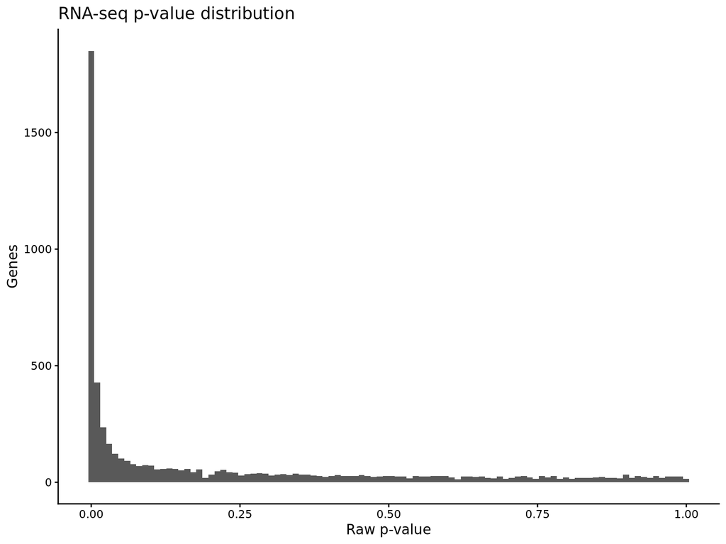

```r
ggplot(res, aes(pvalue)) +
  geom_histogram(bins = 100) +
  labs(
    title = "RNA-seq p-value distribution",
    x = "Raw p-value",
    y = "Genes"
  )
```

# 4. Volcano plot using named columns

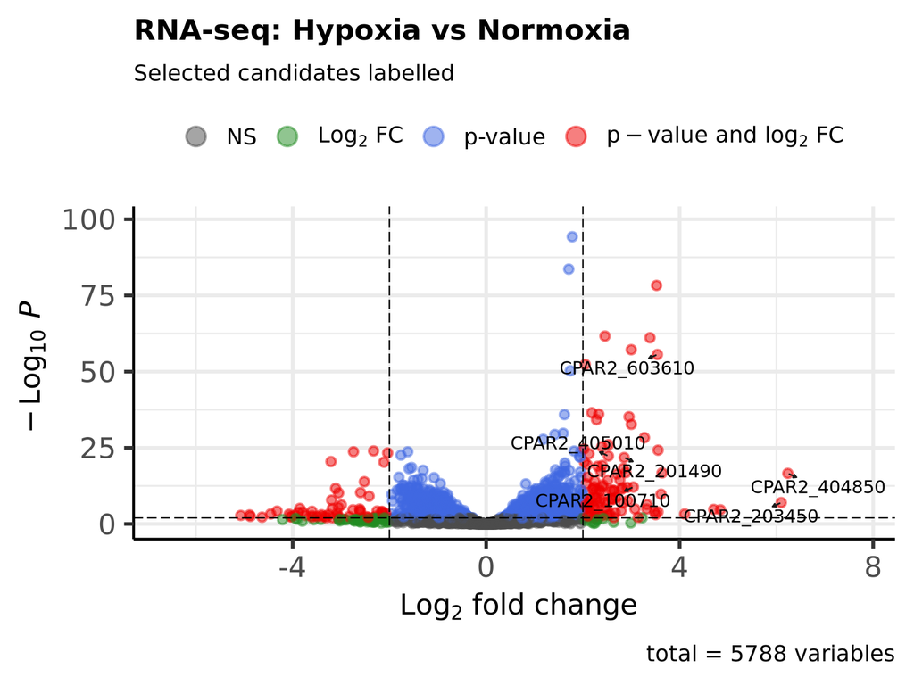

```r
if (requireNamespace("EnhancedVolcano", quietly = TRUE)) {
  EnhancedVolcano::EnhancedVolcano(
    res,
    lab = res$gene,
    x = "log2FoldChange",
    y = "padj",
    selectLab = unique(c(candidate_genes, excluded_gene)),
    FCcutoff = lfc_visual,
    pCutoff = alpha_main,
    title = "RNA-seq: Hypoxia vs Normoxia",
    subtitle = "Selected candidates labelled",
    pointSize = 2,
    labSize = 4,
    drawConnectors = TRUE
  )
} else {
  ggplot(res, aes(log2FoldChange, neglog10padj)) +
    geom_point(alpha = 0.35) +
    geom_vline(xintercept = c(-lfc_visual, lfc_visual), linetype = 2) +
    geom_hline(yintercept = -log10(alpha_main), linetype = 2) +
    labs(
      title = "RNA-seq volcano plot",
      x = "log2 fold change (H/N)",
      y = "-log10 adjusted p-value"
    )
}
```

# 5. MA plot

[figure not shown]

```r
plotMA(
  res_obj,
  alpha = alpha_main,
  ylim = c(-6, 6),
  main = paste0("RNA-seq MA plot; FDR < ", alpha_main)
)
abline(h = c(-1, 1), lty = 2)
```

# 6. Log2 fold-change shrinkage

`apeglm` is preferred when installed. If unavailable, the script falls back to DESeq2’s normal shrinkage.

```r
coef_names <- resultsNames(dds)
coef_HN <- grep("condition_H_vs_N", coef_names, value = TRUE)

if (length(coef_HN) != 1) {
  stop(
    "Could not find coefficient condition_H_vs_N. Check resultsNames(dds) and factor coding."
  )
}

if (requireNamespace("apeglm", quietly = TRUE)) {
  shrink_type <- "apeglm"
} else {
  shrink_type <- "normal"
  message("Package 'apeglm' not installed; using type='normal'. Install apeglm for the preferred analysis.")
}

res_shrunk_obj <- lfcShrink(
  dds,
  coef = coef_HN,
  type = shrink_type
)
```

```
## using 'apeglm' for LFC shrinkage. If used in published research, please cite:
##     Zhu, A., Ibrahim, J.G., Love, M.I. (2018) Heavy-tailed prior distributions for
##     sequence count data: removing the noise and preserving large differences.
##     Bioinformatics. https://doi.org/10.1093/bioinformatics/bty895
```

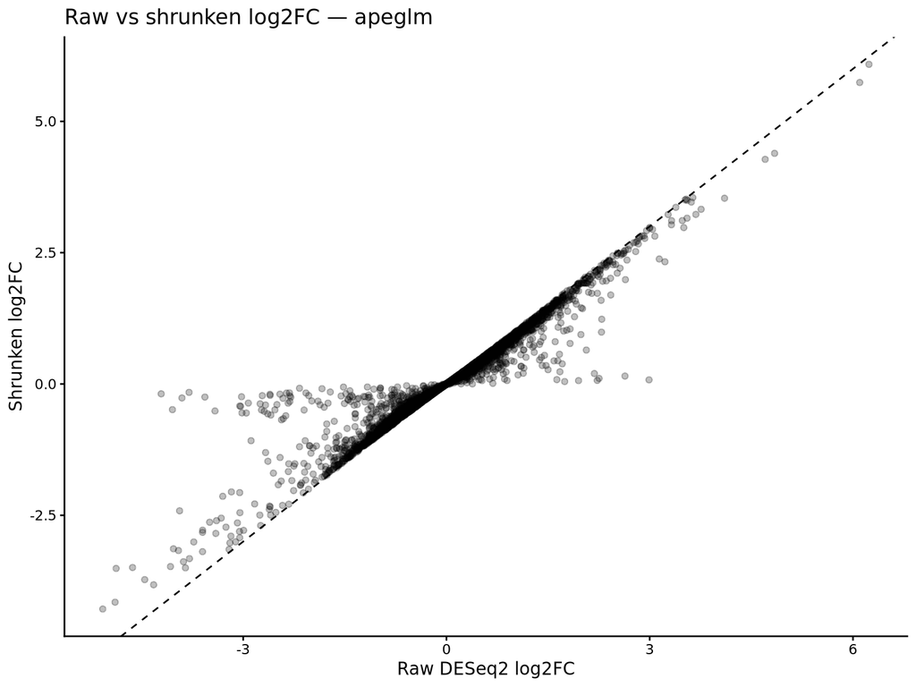

```r
res_shrunk <- as.data.frame(res_shrunk_obj)
res_shrunk$gene <- rownames(res_shrunk)

res$shrunkLFC <- res_shrunk[res$gene, "log2FoldChange"]

ggplot(res, aes(log2FoldChange, shrunkLFC)) +
  geom_point(alpha = 0.25) +
  geom_abline(slope = 1, intercept = 0, linetype = 2) +
  labs(
    title = paste("Raw vs shrunken log2FC —", shrink_type),
    x = "Raw DESeq2 log2FC",
    y = "Shrunken log2FC"
  )
```

# 7. Formal effect-size testing

Rather than testing only `LFC != 0` and applying a hard fold-change cutoff afterward, test whether `|LFC|` exceeds a biologically meaningful threshold.

```r
res_effect_obj <- results(
  dds,
  contrast = c("condition", "H", "N"),
  lfcThreshold = lfc_test,
  altHypothesis = "greaterAbs",
  alpha = 0.05
)

res_effect <- as.data.frame(res_effect_obj)
res_effect$gene <- rownames(res_effect)
res$effectTestPadj <- res_effect[res$gene, "padj"]

cat(
  "Genes with evidence that |log2FC| >", lfc_test,
  "at FDR < 0.05:",
  sum(res$effectTestPadj < 0.05, na.rm = TRUE),
  "\n"
)
```

```
## Genes with evidence that |log2FC| > 1 at FDR < 0.05: 134
```

# 8. Optional apeglm s-values

```r
res$svalue <- NA_real_

if (requireNamespace("apeglm", quietly = TRUE)) {
  s_obj <- lfcShrink(
    dds,
    coef = coef_HN,
    type = "apeglm",
    lfcThreshold = lfc_test,
    svalue = TRUE
  )
  s_df <- as.data.frame(s_obj)
  s_df$gene <- rownames(s_df)
  if ("svalue" %in% colnames(s_df)) {
    res$svalue <- s_df[res$gene, "svalue"]
  }
}
```

```
## using 'apeglm' for LFC shrinkage. If used in published research, please cite:
##     Zhu, A., Ibrahim, J.G., Love, M.I. (2018) Heavy-tailed prior distributions for
##     sequence count data: removing the noise and preserving large differences.
##     Bioinformatics. https://doi.org/10.1093/bioinformatics/bty895
```

```
## computing FSOS 'false sign or small' s-values (T=1)
```

# 9. Abundance, uncertainty and Cook’s distance

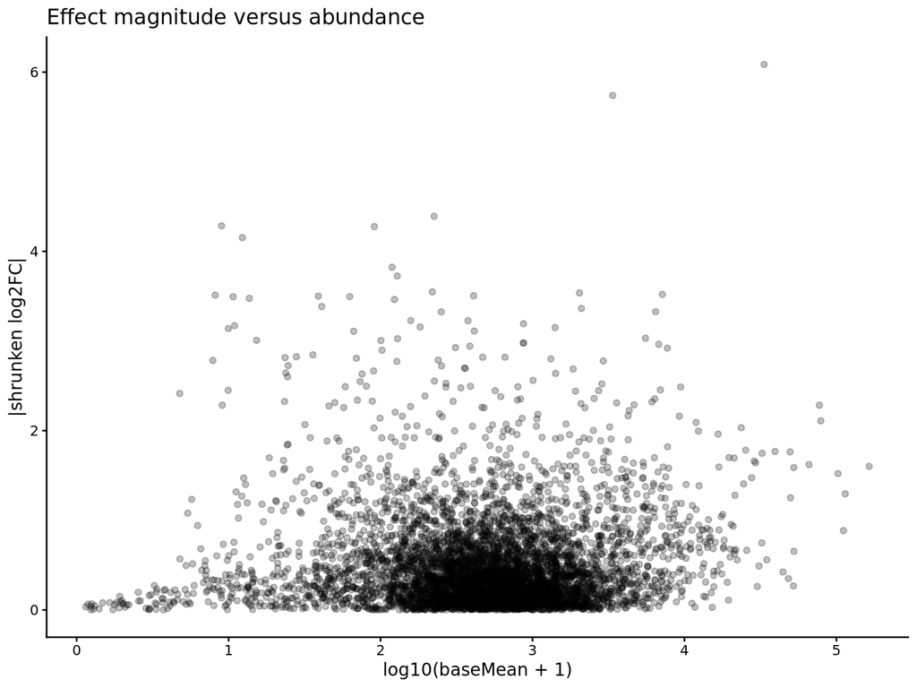

```r
cooks <- assays(dds)[["cooks"]]
maxCook <- apply(cooks, 1, max, na.rm = TRUE)
res$maxCook <- maxCook[res$gene]

ggplot(res, aes(log10(baseMean + 1), abs(shrunkLFC))) +
  geom_point(alpha = 0.25) +
  labs(
    title = "Effect magnitude versus abundance",
    x = "log10(baseMean + 1)",
    y = "|shrunken log2FC|"
  )
```

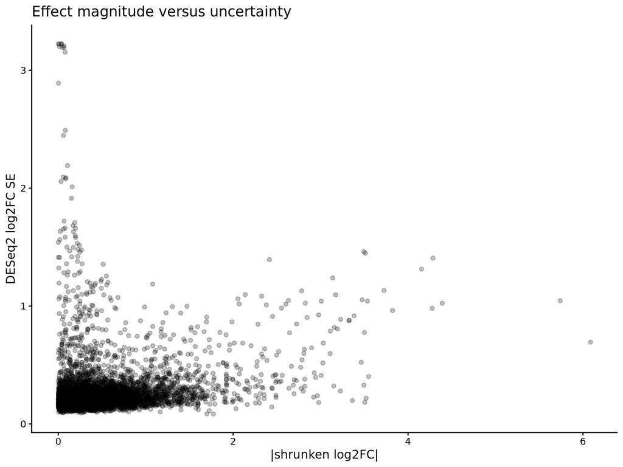

```r
ggplot(res, aes(abs(shrunkLFC), lfcSE)) +
  geom_point(alpha = 0.25) +
  labs(
    title = "Effect magnitude versus uncertainty",
    x = "|shrunken log2FC|",
    y = "DESeq2 log2FC SE"
  )
```

# 10. Candidate-level replicate plots

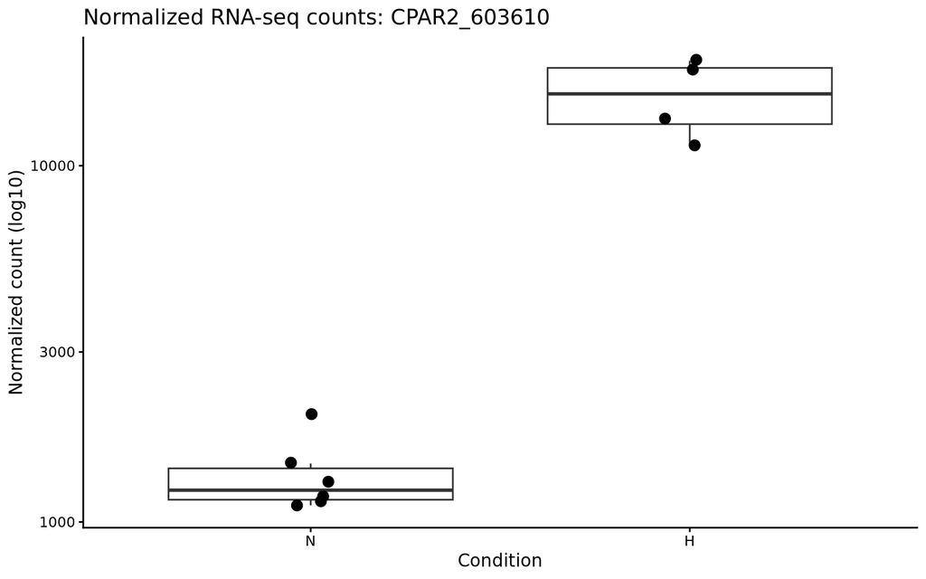

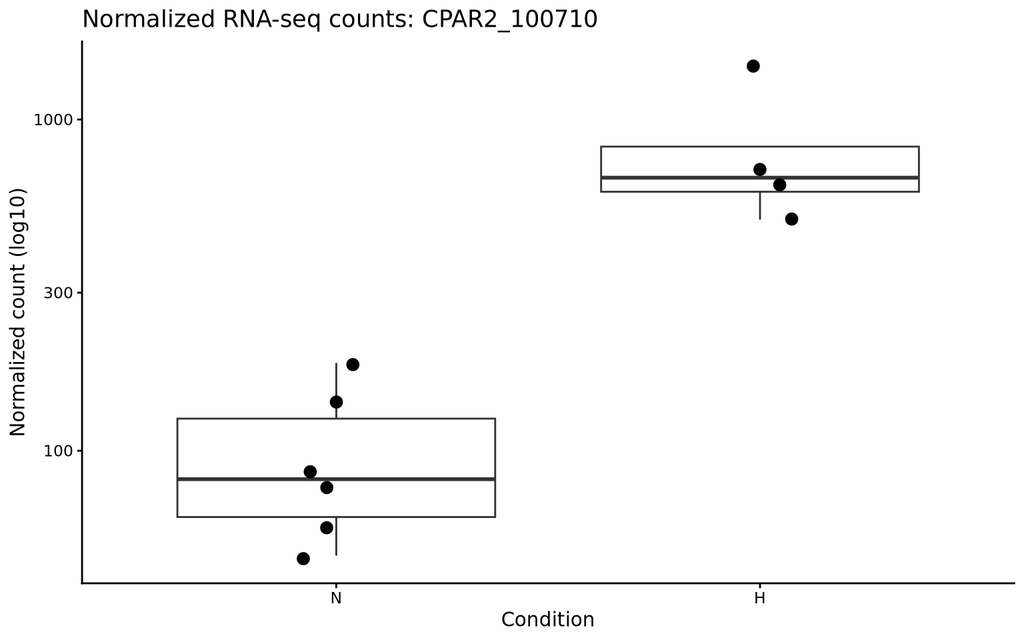

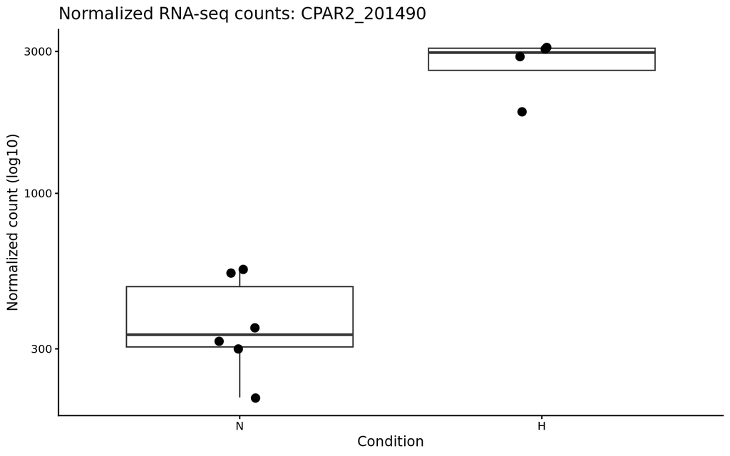

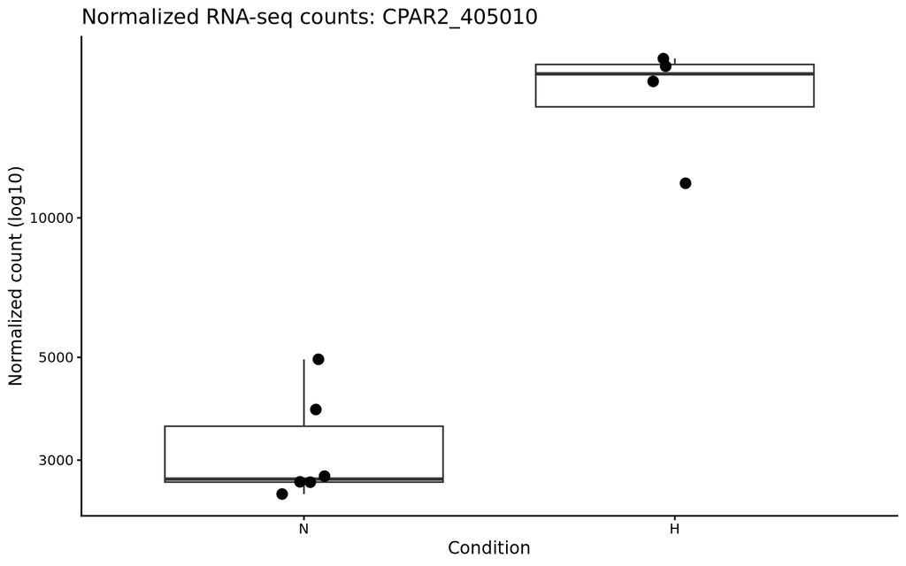

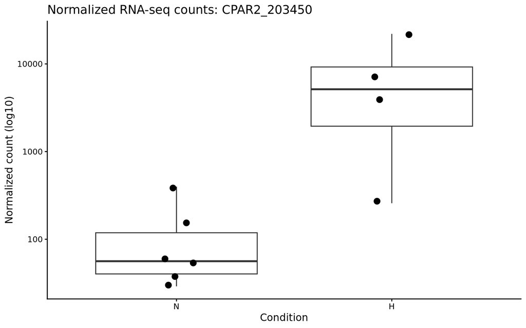

```r
vsd <- vst(dds, blind = FALSE)
candidate_present <- intersect(candidate_genes, rownames(dds))

for (g in candidate_present) {
  dat <- plotCounts(
    dds,
    gene = g,
    intgroup = "condition",
    returnData = TRUE
  )

  p <- ggplot(dat, aes(condition, count)) +
    geom_boxplot(outlier.shape = NA) +
    geom_jitter(width = 0.08, size = 2.8) +
    scale_y_log10() +
    labs(
      title = paste("Normalized RNA-seq counts:", g),
      x = "Condition",
      y = "Normalized count (log10)"
    )
  print(p)
}
```

# 11. Threshold-sensitivity grid

This shows how many genes would be called significant under many reasonable choices instead of one arbitrary threshold.

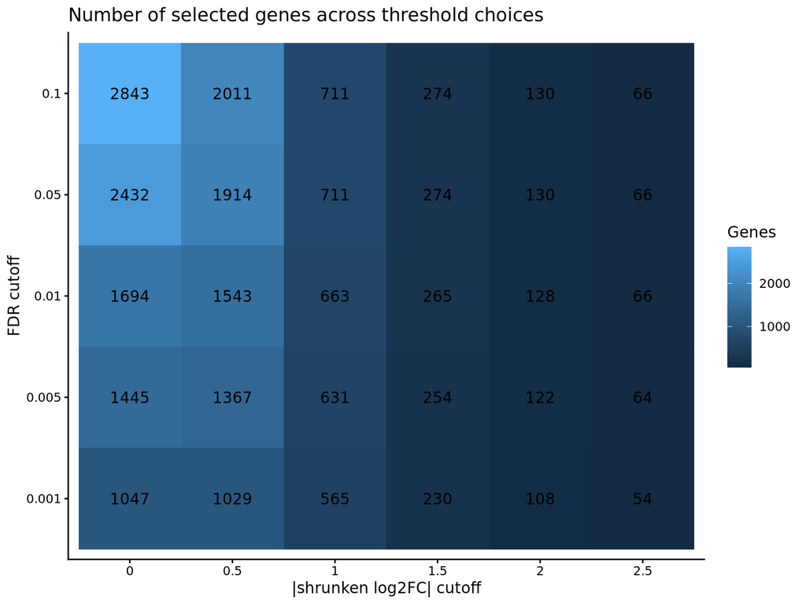

```r
fdr_grid <- c(0.001, 0.005, 0.01, 0.05, 0.10)
lfc_grid <- c(0, 0.5, 1, 1.5, 2, 2.5)

grid <- expand.grid(
  FDR = fdr_grid,
  absLFC = lfc_grid
)

grid$n_genes <- mapply(
  function(a, l) {
    sum(res$padj < a & abs(res$shrunkLFC) > l, na.rm = TRUE)
  },
  grid$FDR,
  grid$absLFC
)

ggplot(grid, aes(factor(absLFC), factor(FDR), fill = n_genes)) +
  geom_tile() +
  geom_text(aes(label = n_genes)) +
  labs(
    title = "Number of selected genes across threshold choices",
    x = "|shrunken log2FC| cutoff",
    y = "FDR cutoff",
    fill = "Genes"
  )
```

Candidate stability across thresholds:

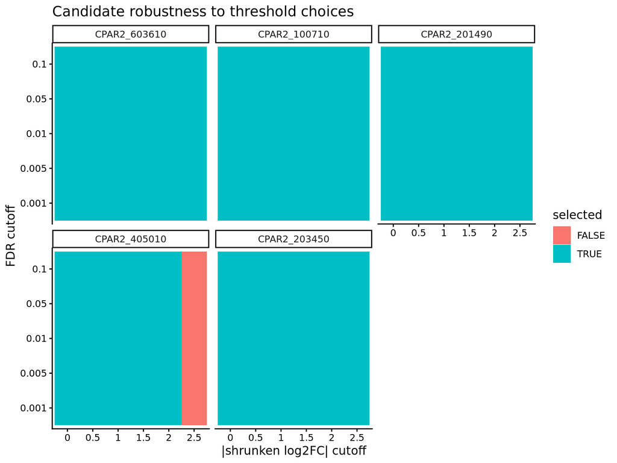

```r
cand_threshold <- expand.grid(
  gene = candidate_present,
  FDR = fdr_grid,
  absLFC = lfc_grid
)

cand_threshold <- cand_threshold |>
  rowwise() |>
  mutate(
    selected = {
      rr <- res[match(gene, res$gene), ]
      !is.na(rr$padj) &&
        rr$padj < FDR &&
        abs(rr$shrunkLFC) > absLFC
    }
  ) |>
  ungroup()

ggplot(
  cand_threshold,
  aes(factor(absLFC), factor(FDR), fill = selected)
) +
  geom_tile() +
  facet_wrap(~ gene) +
  labs(
    title = "Candidate robustness to threshold choices",
    x = "|shrunken log2FC| cutoff",
    y = "FDR cutoff"
  )
```

# 12. Leave-one-sample-out robustness

This is intentionally slower. It refits DESeq2 once per omitted sample.

```
## # A tibble: 5 × 8
##   gene        loo_medianLFC loo_sdLFC loo_minLFC loo_maxLFC loo_propFDR05
##   <chr>               <dbl>     <dbl>      <dbl>      <dbl>         <dbl>
## 1 CPAR2_2034…          6.06    0.528        4.93       6.99             1
## 2 CPAR2_6036…          3.51    0.0884       3.42       3.68             1
## 3 CPAR2_1007…          3.06    0.199        2.62       3.32             1
## 4 CPAR2_2014…          2.82    0.0995       2.72       3.00             1
## 5 CPAR2_4050…          2.48    0.0947       2.44       2.69             1
## # ℹ 2 more variables: loo_medianRank <dbl>, loo_worstRank <dbl>
```

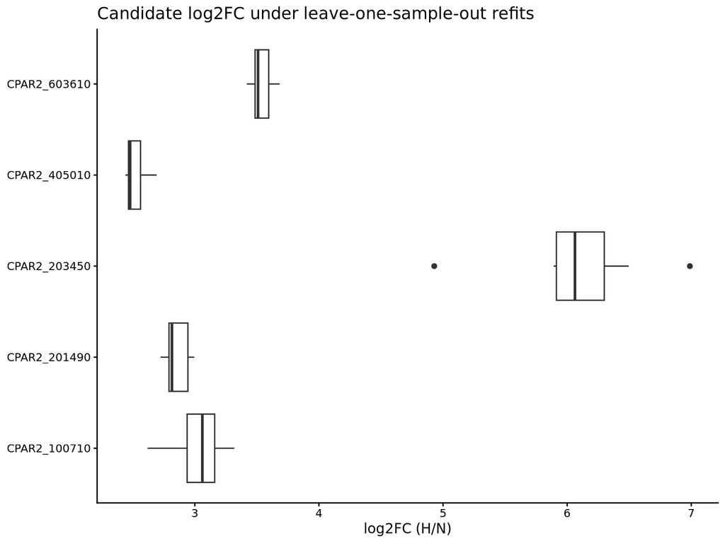

```r
loo_summary <- NULL

if (run_leave_one_out) {
  samples <- colnames(countData)

  loo_list <- lapply(samples, function(s) {
    keep_samples <- setdiff(samples, s)

    tmp_counts <- countData[, keep_samples, drop = FALSE]
    tmp_meta <- colData[keep_samples, , drop = FALSE]

    tmp_dds <- DESeqDataSetFromMatrix(
      countData = round(as.matrix(tmp_counts)),
      colData = tmp_meta,
      design = ~ condition
    )
    tmp_dds <- DESeq(tmp_dds, quiet = TRUE)

    tmp <- as.data.frame(
      results(
        tmp_dds,
        contrast = c("condition", "H", "N"),
        alpha = 0.05
      )
    )

    tmp$gene <- rownames(tmp)
    tmp$removed_sample <- s

    tmp <- tmp |>
      filter(!is.na(log2FoldChange)) |>
      mutate(
        absLFC = abs(log2FoldChange),
        rank_absLFC = rank(-absLFC, ties.method = "average")
      )

    tmp
  })

  loo <- bind_rows(loo_list)

  loo_summary <- loo |>
    group_by(gene) |>
    summarise(
      loo_medianLFC = median(log2FoldChange, na.rm = TRUE),
      loo_sdLFC = sd(log2FoldChange, na.rm = TRUE),
      loo_minLFC = min(log2FoldChange, na.rm = TRUE),
      loo_maxLFC = max(log2FoldChange, na.rm = TRUE),
      loo_propFDR05 = mean(padj < 0.05, na.rm = TRUE),
      loo_medianRank = median(rank_absLFC, na.rm = TRUE),
      loo_worstRank = max(rank_absLFC, na.rm = TRUE),
      .groups = "drop"
    )

  print(
    loo_summary |>
      filter(gene %in% candidate_present) |>
      arrange(loo_medianRank)
  )

  ggplot(
    loo |> filter(gene %in% candidate_present),
    aes(gene, log2FoldChange)
  ) +
    geom_boxplot() +
    coord_flip() +
    labs(
      title = "Candidate log2FC under leave-one-sample-out refits",
      x = NULL,
      y = "log2FC (H/N)"
    )
}
```

# 13. Independent RNA-seq analysis with edgeR

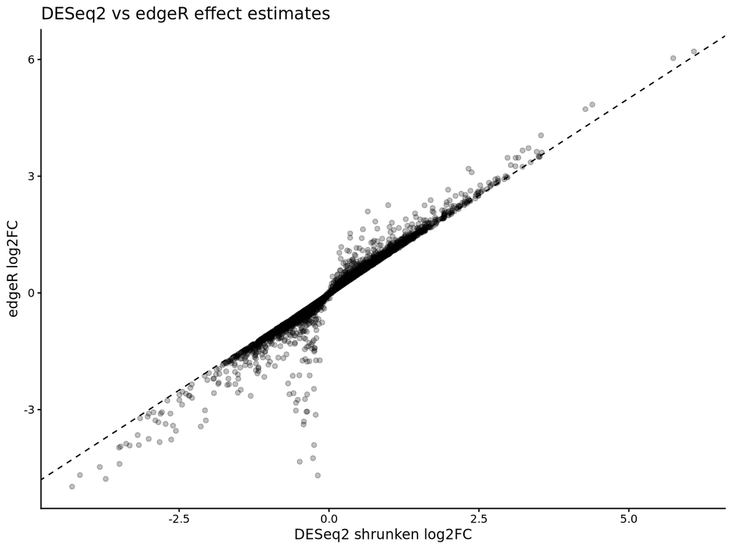

```r
edgeR_table <- NULL

if (run_edgeR) {
  if (requireNamespace("edgeR", quietly = TRUE)) {
    group <- factor(colData$condition)

    y <- edgeR::DGEList(
      counts = countData,
      group = group
    )

    keep <- edgeR::filterByExpr(y, group = group)
    y <- y[keep, , keep.lib.sizes = FALSE]
    y <- edgeR::calcNormFactors(y, method = "TMM")

    design <- model.matrix(~ group)
    y <- edgeR::estimateDisp(y, design)
    fit <- edgeR::glmQLFit(y, design)

    coef_index <- ncol(design)
    qlf <- edgeR::glmQLFTest(fit, coef = coef_index)

    edgeR_table <- edgeR::topTags(qlf, n = Inf)$table
    edgeR_table$gene <- rownames(edgeR_table)

    # Ensure edgeR orientation is H/N; reverse if the coefficient is N-H.
    coef_name <- colnames(design)[coef_index]
    if (grepl("groupN", coef_name)) {
      edgeR_table$logFC <- -edgeR_table$logFC
    }

    edgeR_table$edgeR_rank <- rank(
      -abs(edgeR_table$logFC),
      ties.method = "average"
    )

    ggplot(
      merge(
        res[, c("gene", "shrunkLFC")],
        edgeR_table[, c("gene", "logFC")],
        by = "gene"
      ),
      aes(shrunkLFC, logFC)
    ) +
      geom_point(alpha = 0.25) +
      geom_abline(slope = 1, intercept = 0, linetype = 2) +
      labs(
        title = "DESeq2 vs edgeR effect estimates",
        x = "DESeq2 shrunken log2FC",
        y = "edgeR log2FC"
      )
  } else {
    message("edgeR is not installed; skipping independent RNA-seq analysis.")
  }
}
```

# 14. Load and analyse microarray ratios with limma

The supplied microarray matrix contains replicate **log(H/N) ratios**, so the intercept-only `lmFit(data)` model asks whether the average log-ratio differs from zero.

```r
array_data <- as.matrix(
  read.table(
    microarray_file,
    row.names = 1,
    header = TRUE,
    check.names = FALSE
  )
)

fit_array <- lmFit(array_data)

# Standard empirical Bayes (matches the practical logic).
fit_ebayes <- eBayes(fit_array)
array_standard <- topTable(
  fit_ebayes,
  number = Inf,
  sort.by = "P"
)
array_standard$gene <- rownames(array_standard)

# Robust sensitivity analysis.
fit_robust <- eBayes(fit_array, robust = TRUE)
array_robust <- topTable(
  fit_robust,
  number = Inf,
  sort.by = "P"
)
array_robust$gene <- rownames(array_robust)

# Effect-size test: mean |log ratio| > lfc_test.
fit_treat <- treat(
  fit_array,
  lfc = lfc_test
)
array_treat <- topTreat(
  fit_treat,
  number = Inf
)
array_treat$gene <- rownames(array_treat)

# Replicate-level consistency.
array_rep_stats <- data.frame(
  gene = rownames(array_data),
  array_mean = rowMeans(array_data, na.rm = TRUE),
  array_sd = apply(array_data, 1, sd, na.rm = TRUE),
  array_min = apply(array_data, 1, min, na.rm = TRUE),
  array_max = apply(array_data, 1, max, na.rm = TRUE)
)

head(array_standard)
```

```
##                 logFC  AveExpr        t      P.Value    adj.P.Val
## CPAR2_404850 6.462651 6.462651 71.45643 3.788865e-10 2.093727e-06
## CPAR2_503990 5.168192 5.168192 61.93992 9.047930e-10 2.499943e-06
## CPAR2_502580 3.504953 3.504953 50.62005 3.091002e-09 4.333583e-06
## CPAR2_807620 3.614666 3.614666 50.49767 3.136868e-09 4.333583e-06
## CPAR2_401230 3.328905 3.328905 45.27100 6.097772e-09 5.982882e-06
## CPAG_00607   3.396506 3.396506 43.79661 7.457963e-09 5.982882e-06
##                     B         gene
## CPAR2_404850 13.59386 CPAR2_404850
## CPAR2_503990 13.02649 CPAR2_503990
## CPAR2_502580 12.10863 CPAR2_502580
## CPAR2_807620 12.09684 CPAR2_807620
## CPAR2_401230 11.54690 CPAR2_401230
## CPAG_00607   11.37366   CPAG_00607
```

# 15. Visualize microarray replicate consistency

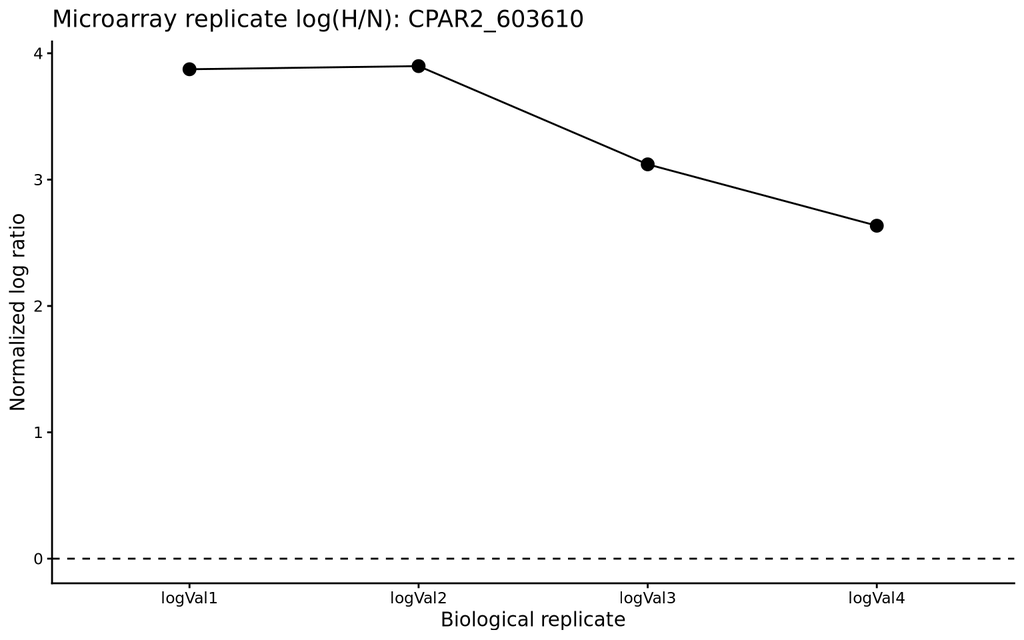

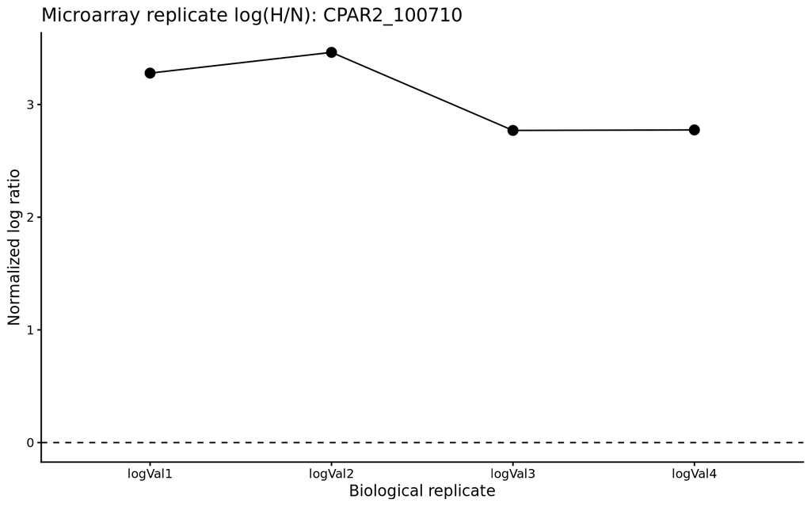

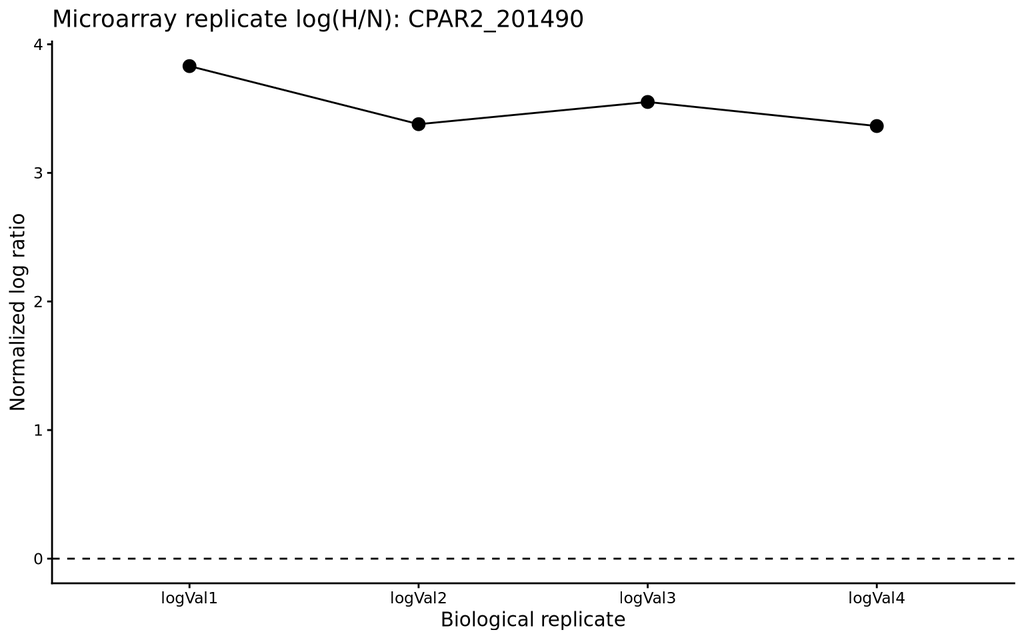

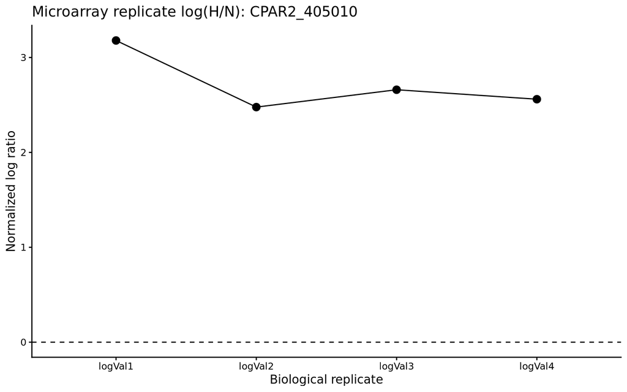

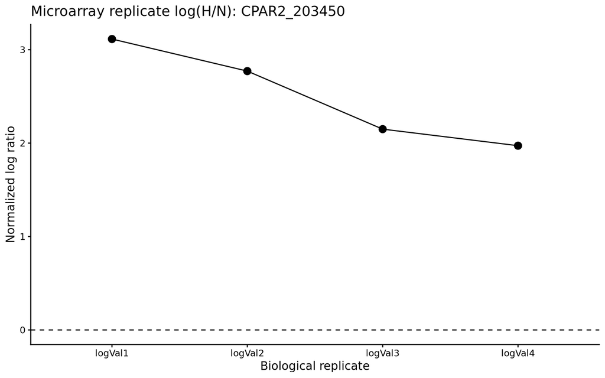

```r
array_candidate_present <- intersect(candidate_genes, rownames(array_data))

for (g in array_candidate_present) {
  df <- data.frame(
    replicate = colnames(array_data),
    log_ratio = as.numeric(array_data[g, ])
  )

  p <- ggplot(df, aes(replicate, log_ratio, group = 1)) +
    geom_hline(yintercept = 0, linetype = 2) +
    geom_point(size = 3) +
    geom_line() +
    labs(
      title = paste("Microarray replicate log(H/N):", g),
      x = "Biological replicate",
      y = "Normalized log ratio"
    )
  print(p)
}
```

# 16. Compare standard limma, robust limma and TREAT

```r
array_compare <- array_standard |>
  select(gene, logFC, adj.P.Val) |>
  rename(
    array_logFC = logFC,
    array_FDR_standard = adj.P.Val
  ) |>
  left_join(
    array_robust |>
      select(gene, adj.P.Val) |>
      rename(array_FDR_robust = adj.P.Val),
    by = "gene"
  ) |>
  left_join(
    array_treat |>
      select(gene, adj.P.Val) |>
      rename(array_FDR_treat = adj.P.Val),
    by = "gene"
  ) |>
  left_join(array_rep_stats, by = "gene")

print(
  array_compare |>
    filter(gene %in% candidate_genes)
)
```

```
##           gene array_logFC array_FDR_standard array_FDR_robust
## 1 CPAR2_201490    3.531186       7.238432e-06     7.384603e-06
## 2 CPAR2_100710    3.071622       3.626108e-05     4.365534e-05
## 3 CPAR2_405010    2.719338       3.997215e-05     4.365534e-05
## 4 CPAR2_603610    3.381963       1.517112e-04     1.799677e-04
## 5 CPAR2_203450    2.501707       2.824438e-04     3.391851e-04
##   array_FDR_treat array_mean  array_sd array_min array_max
## 1    3.953845e-05   3.531186 0.2167879  3.364224  3.830316
## 2    2.816166e-04   3.071622 0.3536293  2.770095  3.462871
## 3    4.111465e-04   2.719338 0.3156200  2.477365  3.179290
## 4    1.368501e-03   3.381963 0.6148848  2.635126  3.898366
## 5    6.391971e-03   2.501707 0.5327761  1.972390  3.114033
```

# 17. Integrate RNA-seq and microarray

```r
merged <- res |>
  select(
    gene, baseMean, log2FoldChange, shrunkLFC, lfcSE, padj,
    effectTestPadj, svalue, maxCook
  ) |>
  left_join(array_compare, by = "gene")

merged <- merged |>
  mutate(
    direction_same =
      !is.na(array_logFC) &
      sign(shrunkLFC) == sign(array_logFC),
    platform_difference = abs(shrunkLFC - array_logFC),
    mean_effect = rowMeans(
      cbind(shrunkLFC, array_logFC),
      na.rm = TRUE
    )
  )

cat("Cross-platform Pearson correlation:\n")
```

```
## Cross-platform Pearson correlation:
```

```r
print(
  cor(
    merged$shrunkLFC,
    merged$array_logFC,
    method = "pearson",
    use = "complete.obs"
  )
)
```

```
## [1] 0.6507698
```

```r
cat("Cross-platform Spearman correlation:\n")
```

```
## Cross-platform Spearman correlation:
```

```r
print(
  cor(
    merged$shrunkLFC,
    merged$array_logFC,
    method = "spearman",
    use = "complete.obs"
  )
)
```

```
## [1] 0.6572198
```

# 18. RNA-seq versus microarray scatter

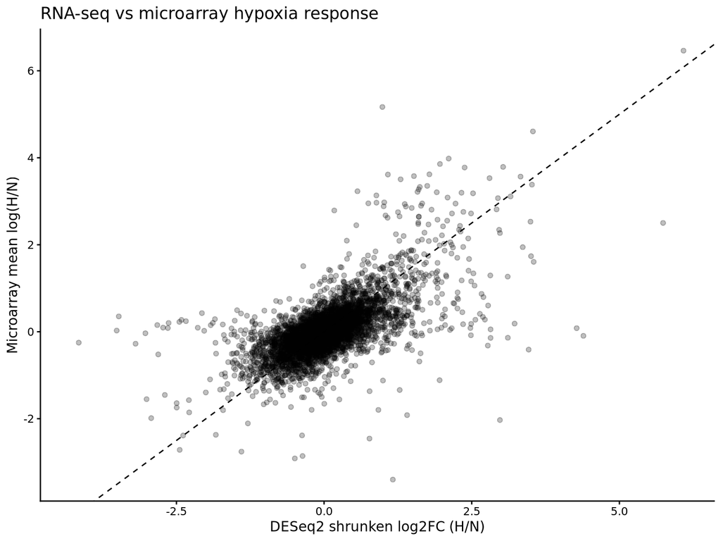

```r
ggplot(
  merged,
  aes(shrunkLFC, array_logFC)
) +
  geom_point(alpha = 0.25) +
  geom_abline(slope = 1, intercept = 0, linetype = 2) +
  labs(
    title = "RNA-seq vs microarray hypoxia response",
    x = "DESeq2 shrunken log2FC (H/N)",
    y = "Microarray mean log(H/N)"
  )
```

# 19. Bland-Altman-style platform agreement

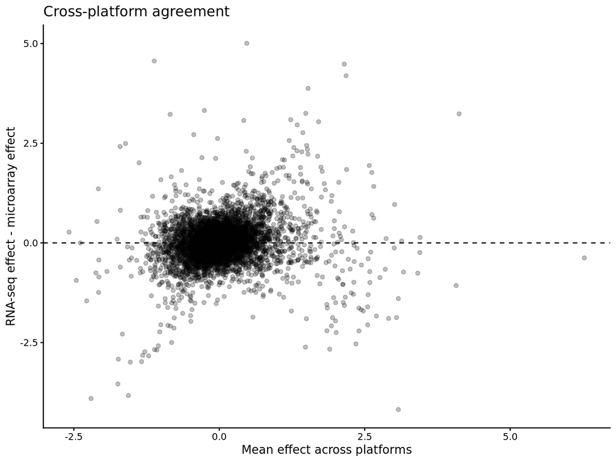

```r
ba <- merged |>
  filter(
    is.finite(shrunkLFC),
    is.finite(array_logFC)
  ) |>
  mutate(
    platform_mean = (shrunkLFC + array_logFC) / 2,
    platform_diff = shrunkLFC - array_logFC
  )

ggplot(ba, aes(platform_mean, platform_diff)) +
  geom_point(alpha = 0.25) +
  geom_hline(yintercept = 0, linetype = 2) +
  labs(
    title = "Cross-platform agreement",
    x = "Mean effect across platforms",
    y = "RNA-seq effect - microarray effect"
  )
```

# 20. Find cross-platform discordant genes

```r
discordant <- merged |>
  filter(
    !is.na(array_logFC),
    abs(shrunkLFC) >= 1,
    abs(array_logFC) >= 1,
    !direction_same
  ) |>
  arrange(desc(abs(shrunkLFC - array_logFC)))

head(discordant, 30)
```

```
##           gene   baseMean log2FoldChange shrunkLFC     lfcSE
## 1 CPAR2_802720  870.65030       3.503234  2.977271 0.9252023
## 2 CPAR2_108370 1938.72077       1.689003  1.163970 0.6501874
## 3 CPAR2_106700   35.31632       1.659997  1.405825 0.4733405
## 4 CPAR2_207780 1752.87093       2.092112  1.955893 0.3873054
## 5 CPAR2_100870  213.12811       1.890352  1.279963 0.7184339
##           padj effectTestPadj      svalue    maxCook array_logFC
## 1 8.614758e-04     0.11269041 0.004517877 0.46254754   -2.030915
## 2 2.614664e-02     1.00000000 0.131221098 0.34309548   -3.399933
## 3 2.141687e-03     1.00000000 0.053310342 0.09153175   -1.917407
## 4 9.450212e-07     0.08686326 0.001462606 0.15833830   -1.114264
## 5 2.423669e-02     1.00000000 0.119331339 0.09217962   -1.339349
##   array_FDR_standard array_FDR_robust array_FDR_treat array_mean
## 1       2.080929e-04     2.556724e-04     0.009452694  -2.030915
## 2       4.166148e-05     5.356412e-05     0.000288846  -3.399933
## 3       6.603823e-04     7.572764e-04     0.046883131  -1.917407
## 4       2.154327e-03     2.430953e-03     0.999999995  -1.114264
## 5       1.517112e-04     1.563146e-04     0.123223054  -1.339349
##    array_sd array_min  array_max direction_same platform_difference
## 1 0.3826557 -2.573670 -1.6779339          FALSE            5.008186
## 2 0.4267106 -3.854502 -2.9024255          FALSE            4.563904
## 3 0.5115845 -2.545412 -1.4938122          FALSE            3.323232
## 4 0.4059501 -1.559628 -0.6832965          FALSE            3.070156
## 5 0.1847975 -1.569592 -1.1172837          FALSE            2.619311
##   mean_effect
## 1  0.47317810
## 2 -1.11798134
## 3 -0.25579105
## 4  0.42081462
## 5 -0.02969294
```

# 21. Find genes excluded by the practical’s hard cutoff but promising now

```r
merged <- merged |>
  mutate(
    practical_selected =
      !is.na(padj) &
      padj < alpha_main &
      abs(log2FoldChange) > lfc_visual,

    modern_strong =
      !is.na(padj) &
      padj < 0.05 &
      abs(shrunkLFC) > 1 &
      !is.na(array_FDR_standard) &
      array_FDR_standard < 0.05 &
      direction_same
  )

rescued <- merged |>
  filter(
    !practical_selected,
    modern_strong,
    gene != excluded_gene
  ) |>
  arrange(padj)

head(rescued, 30)
```

```
##            gene    baseMean log2FoldChange shrunkLFC      lfcSE
## 1  CPAR2_502980  1941.33131       1.780547  1.773574 0.08442317
## 2  CPAR2_206900 19639.42207       1.708129  1.699903 0.08599020
## 3  CPAR2_102080  2249.85644       1.739442  1.726794 0.11263159
## 4  CPAR2_103000  1615.11898       1.618381  1.602323 0.12336173
## 5  CPAR2_200170  1364.42285       1.593233  1.574404 0.13306004
## 6  CPAR2_109030   365.31659       1.419424  1.402953 0.11932131
## 7  CPAR2_205030  2023.72620       1.179553  1.166247 0.10193285
## 8  CPAR2_808380   488.99862       1.953839  1.923214 0.18221647
## 9  CPAR2_701730   905.19326      -1.762242 -1.733384 0.16855391
## 10 CPAR2_101480  4266.49930       1.931218  1.898933 0.18691194
## 11 CPAR2_105550  3288.17062       1.939958  1.907332 0.18797755
## 12 CPAR2_602050  1103.09842       1.627646  1.598821 0.16520133
## 13 CPAR2_401470  1922.56036       1.633697  1.603364 0.16984881
## 14 CPAR2_403460  1231.87427      -1.541564 -1.511368 0.16243475
```

[output cut: 140 more lines]

# 22. Find fragile hits from the original filter

```r
fragile <- merged |>
  filter(
    practical_selected,
    gene != excluded_gene
  ) |>
  mutate(
    low_abundance = baseMean < quantile(baseMean, 0.20, na.rm = TRUE),
    high_uncertainty = lfcSE > quantile(lfcSE, 0.80, na.rm = TRUE),
    poor_platform_support =
      is.na(array_FDR_standard) |
      array_FDR_standard >= 0.05 |
      !direction_same
  ) |>
  filter(
    low_abundance |
    high_uncertainty |
    poor_platform_support
  ) |>
  arrange(desc(high_uncertainty), desc(poor_platform_support))

head(fragile, 30)
```

```
##            gene    baseMean log2FoldChange  shrunkLFC     lfcSE
## 1   CapafMp06.4    9.942816      -3.955359 -3.1715505 1.0957022
## 2  CPAR2_213800   40.044971      -3.881978 -3.3843952 0.9172802
## 3  CPAR2_406090    8.933948      -3.048405 -2.4504741 0.9121543
## 4  CPAR2_407570   26.950013      -3.600191 -2.8246075 1.0247748
## 5  CPAR2_701480   12.689662      -4.073820 -3.4764108 1.0530327
## 6  CPAR2_802720  870.650298       3.503234  2.9772713 0.9252023
## 7  CPAR2_300120  172.574239      -3.174241 -2.0544027 1.0619543
## 8     CapafMp16    7.996412      -5.073008 -4.2849766 1.4073370
## 9   CapafMp06.3    9.713090      -4.632985 -3.4945604 1.4615153
## 10    CapafMp17  249.556468      -3.793228 -3.3249961 0.8758848
## 11    CapafMp02  127.902408      -4.453916 -3.7251077 1.1321415
## 12 CPAR2_801290   74.571280      -3.495024 -2.6321830 1.0473143
## 13 CPAR2_402890    8.964331      -4.029863 -3.1385221 1.2392025
## 14    CapafMp14   14.275277      -3.729919 -3.0078808 1.0417410
```

[output cut: 171 more lines]

# 23. Add leave-one-out and edgeR evidence

```r
master <- merged

if (!is.null(loo_summary)) {
  master <- master |>
    left_join(loo_summary, by = "gene")
}

if (!is.null(edgeR_table)) {
  master <- master |>
    left_join(
      edgeR_table |>
        select(gene, edgeR_logFC = logFC, edgeR_FDR = FDR, edgeR_rank),
      by = "gene"
    )
}
```

# 24. Rank-product consensus

Ranks are more robust than directly combining incomparable p-value scales.

```r
rank_high <- function(x) {
  rank(-x, ties.method = "average", na.last = "keep")
}

rank_low <- function(x) {
  rank(x, ties.method = "average", na.last = "keep")
}

master <- master |>
  mutate(
    rank_DESeq2_effect = rank_high(abs(shrunkLFC)),
    rank_DESeq2_FDR = rank_low(padj),
    rank_array_effect = rank_high(abs(array_logFC)),
    rank_array_FDR = rank_low(array_FDR_standard)
  )

rank_cols <- c(
  "rank_DESeq2_effect",
  "rank_DESeq2_FDR",
  "rank_array_effect",
  "rank_array_FDR"
)

if ("edgeR_rank" %in% colnames(master)) {
  rank_cols <- c(rank_cols, "edgeR_rank")
}

rank_mat <- as.matrix(master[, rank_cols, drop = FALSE])

master$rank_product <- apply(
  rank_mat,
  1,
  function(x) {
    x <- x[is.finite(x)]
    if (length(x) < 2) return(NA_real_)
    exp(mean(log(x)))
  }
)

master$rank_product_rank <- rank(
  master$rank_product,
  ties.method = "average",
  na.last = "keep"
)
```

# 25. Statistical percentile score

This keeps biology separate initially.

```r
pct_high <- function(x) {
  out <- rep(NA_real_, length(x))
  ok <- is.finite(x)
  out[ok] <- dplyr::percent_rank(x[ok])
  out
}

pct_low <- function(x) {
  pct_high(-x)
}

master <- master |>
  mutate(
    score_effect = pct_high(abs(shrunkLFC)),
    score_significance = pct_low(padj),
    score_precision = pct_low(lfcSE),
    score_abundance = pct_high(log1p(baseMean)),
    score_array_effect = pct_high(abs(array_logFC)),
    score_array_significance = pct_low(array_FDR_standard),
    score_platform_agreement = pct_low(platform_difference)
  )

if ("loo_propFDR05" %in% colnames(master)) {
  master$score_loo <- master$loo_propFDR05
} else {
  master$score_loo <- NA_real_
}

if ("edgeR_FDR" %in% colnames(master)) {
  master$score_edgeR <- pct_low(master$edgeR_FDR)
} else {
  master$score_edgeR <- NA_real_
}

score_cols <- c(
  "score_effect",
  "score_significance",
  "score_precision",
  "score_abundance",
  "score_array_effect",
  "score_array_significance",
  "score_platform_agreement",
  "score_loo",
  "score_edgeR"
)

master$stat_score <- apply(
  as.matrix(master[, score_cols, drop = FALSE]),
  1,
  function(x) mean(x, na.rm = TRUE)
)

master <- master |>
  filter(gene != excluded_gene) |>
  arrange(desc(stat_score))

head(
  master |>
    select(
      gene, stat_score, rank_product_rank,
      shrunkLFC, padj, baseMean, lfcSE,
      array_logFC, array_FDR_standard,
      platform_difference,
      any_of(c("loo_propFDR05", "loo_medianRank", "edgeR_logFC", "edgeR_FDR"))
    ),
  30
)
```

```
##            gene stat_score rank_product_rank  shrunkLFC         padj
## 1  CPAR2_106960  0.9836235                39  2.0326390 4.386783e-53
## 2  CPAR2_808200  0.9492519               139 -1.2795491 2.446354e-18
## 3  CPAR2_109530  0.9410130               168  1.3364188 6.752195e-15
## 4  CPAR2_102080  0.9361514                89  1.7267944 5.351330e-51
## 5  CPAR2_400470  0.9234114               276 -1.0700558 5.865543e-10
## 6  CPAR2_200290  0.9215347                99 -1.5622657 7.247229e-19
## 7  CPAR2_101620  0.9214498                57  2.1611809 3.081430e-37
## 8  CPAR2_405900  0.9184683                21  2.3018992 9.007169e-37
## 9  CPAR2_211730  0.9181395               196  1.1934693 1.803587e-14
## 10 CPAR2_602160  0.9180230               184 -1.3877891 1.203483e-12
## 11 CPAR2_205940  0.9147796               627 -0.6993650 4.260932e-08
## 12 CPAR2_105300  0.9147487               313  1.1876069 1.270787e-13
## 13 CPAR2_502980  0.9111459                25  1.7735740 5.595772e-95
## 14 CPAR2_400810  0.9101928               443 -0.9593195 2.028312e-09
```

[output cut: 109 more lines]

# 26. Pareto frontier

A gene is Pareto-dominated if another gene is at least as good on every selected criterion and strictly better on at least one.

```r
pareto_vars <- c(
  "score_effect",
  "score_significance",
  "score_precision",
  "score_array_significance",
  "score_platform_agreement"
)

# Pareto analysis is most useful among already plausible candidates.
# Limiting it to the strongest statistical candidates also avoids an
# unnecessarily expensive O(n^2) comparison over all ~5,800 genes.
pareto_df <- master |>
  dplyr::filter(
    dplyr::if_all(
      dplyr::all_of(pareto_vars),
      ~ is.finite(.x)
    ),
    is.finite(stat_score)
  ) |>
  dplyr::arrange(dplyr::desc(stat_score))

# Keep at most the 500 strongest candidates.
n_pareto <- min(500, nrow(pareto_df))
pareto_df <- dplyr::slice_head(pareto_df, n = n_pareto)

cat("Genes entering Pareto analysis:", nrow(pareto_df), "\n")
```

```
## Genes entering Pareto analysis: 500
```

```r
if (nrow(pareto_df) > 0) {
  X <- as.matrix(
    pareto_df[, pareto_vars, drop = FALSE]
  )
  storage.mode(X) <- "double"

  dominated <- rep(FALSE, nrow(X))

  # A point i is dominated if another point is >= it on every criterion
  # and > it on at least one criterion.
  for (i in seq_len(nrow(X))) {
    ge_all <- rowSums(
      sweep(X, 2, X[i, ], FUN = ">=")
    ) == ncol(X)

    gt_any <- rowSums(
      sweep(X, 2, X[i, ], FUN = ">")
    ) > 0

    ge_all[i] <- FALSE
    dominated[i] <- any(ge_all & gt_any)
  }

  pareto_df$dominated <- dominated

  pareto_front <- pareto_df |>
    dplyr::filter(!dominated) |>
    dplyr::arrange(dplyr::desc(stat_score))

  cat(
    "Genes on selected statistical Pareto frontier:",
    nrow(pareto_front),
    "\n"
  )

  print(
    head(
      pareto_front |>
        dplyr::select(
          gene,
          stat_score,
          dplyr::all_of(pareto_vars)
        ),
      30
    )
  )
} else {
  pareto_front <- pareto_df
  warning("No genes had complete finite values for the Pareto criteria.")
}
```

```
## Genes on selected statistical Pareto frontier: 52
##            gene stat_score score_effect score_significance
## 1  CPAR2_106960  0.9836235    0.9780543          0.9987896
## 2  CPAR2_808200  0.9492519    0.9296699          0.9918727
## 3  CPAR2_102080  0.9361514    0.9683774          0.9986166
## 4  CPAR2_200290  0.9215347    0.9578365          0.9922186
## 5  CPAR2_101620  0.9214498    0.9809919          0.9984437
## 6  CPAR2_405900  0.9184683    0.9837567          0.9982708
## 7  CPAR2_205940  0.9147796    0.7719025          0.9489884
## 8  CPAR2_502980  0.9111459    0.9697598          1.0000000
## 9  CPAR2_400570  0.9080363    0.9863487          0.9994812
## 10 CPAR2_103400  0.9077223    0.9839295          0.9915269
## 11 CPAR2_210890  0.9054318    0.8669431          0.9604012
## 12 CPAR2_402940  0.9044339    0.9930880          0.9979250
## 13 CPAR2_603610  0.9024535    0.9982720          0.9989625
```

[output cut: 48 more lines]

# 27. Decision-weight sensitivity

This asks whether genes remain highly ranked under thousands of reasonable weighting schemes.

```
##            gene P_top5_weights P_top10_weights
## 1  CPAR2_106960         0.9908          0.9952
## 2  CPAR2_808200         0.6012          0.8350
## 3  CPAR2_210890         0.4248          0.6144
## 4  CPAR2_109530         0.4044          0.6422
## 5  CPAR2_102080         0.3960          0.5552
## 6  CPAR2_502980         0.2958          0.3948
## 7  CPAR2_103400         0.2634          0.3510
## 8  CPAR2_206900         0.1908          0.2706
## 9  CPAR2_205940         0.1776          0.3788
## 10 CPAR2_400570         0.1760          0.3266
## 11 CPAR2_401990         0.1340          0.4084
## 12 CPAR2_211730         0.1334          0.5112
## 13 CPAR2_101020         0.1284          0.2310
## 14 CPAR2_603010         0.1076          0.1734
```

[output cut: 16 more lines]

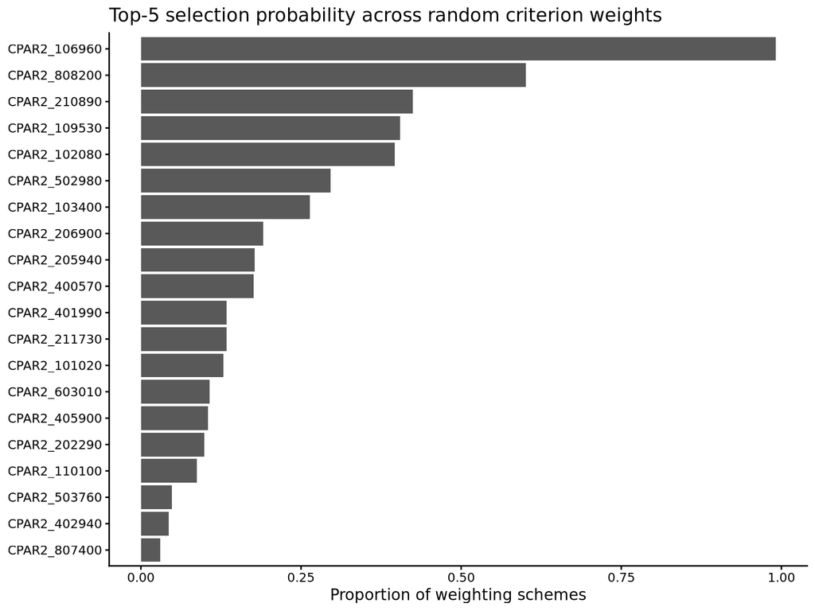

```r
weight_summary <- NULL

if (run_weight_sensitivity) {
  decision_vars <- c(
    "score_effect",
    "score_significance",
    "score_precision",
    "score_array_significance",
    "score_platform_agreement"
  )

  decision_df <- master |>
    filter(if_all(all_of(decision_vars), is.finite))

  Xd <- as.matrix(decision_df[, decision_vars])

  W <- matrix(
    rexp(n_weight_draws * length(decision_vars)),
    nrow = n_weight_draws,
    ncol = length(decision_vars)
  )
  W <- W / rowSums(W)

  score_matrix <- Xd %*% t(W)

  top5_count <- integer(nrow(decision_df))
  top10_count <- integer(nrow(decision_df))

  for (j in seq_len(ncol(score_matrix))) {
    ord <- order(score_matrix[, j], decreasing = TRUE)
    top5_count[ord[seq_len(min(5, length(ord)))]] <-
      top5_count[ord[seq_len(min(5, length(ord)))]] + 1
    top10_count[ord[seq_len(min(10, length(ord)))]] <-
      top10_count[ord[seq_len(min(10, length(ord)))]] + 1
  }

  weight_summary <- data.frame(
    gene = decision_df$gene,
    P_top5_weights = top5_count / n_weight_draws,
    P_top10_weights = top10_count / n_weight_draws
  ) |>
    arrange(desc(P_top5_weights), desc(P_top10_weights))

  print(head(weight_summary, 30))

  ggplot(
    head(weight_summary, 20),
    aes(reorder(gene, P_top5_weights), P_top5_weights)
  ) +
    geom_col() +
    coord_flip() +
    labs(
      title = "Top-5 selection probability across random criterion weights",
      x = NULL,
      y = "Proportion of weighting schemes"
    )
}
```

# 28. Combine robustness dimensions

```r
final_master <- master

if (!is.null(weight_summary)) {
  final_master <- final_master |>
    left_join(weight_summary, by = "gene")
}

if ("loo_propFDR05" %in% colnames(final_master) &&
    "P_top5_weights" %in% colnames(final_master)) {
  final_master <- final_master |>
    mutate(
      combined_robustness =
        sqrt(pmax(loo_propFDR05, 0) * pmax(P_top5_weights, 0))
    )
} else {
  final_master$combined_robustness <- NA_real_
}

final_master <- final_master |>
  arrange(
    desc(combined_robustness),
    desc(stat_score)
  )
```

# 29. Five-gene panel visualization

This is exploratory only because the sample size is small.

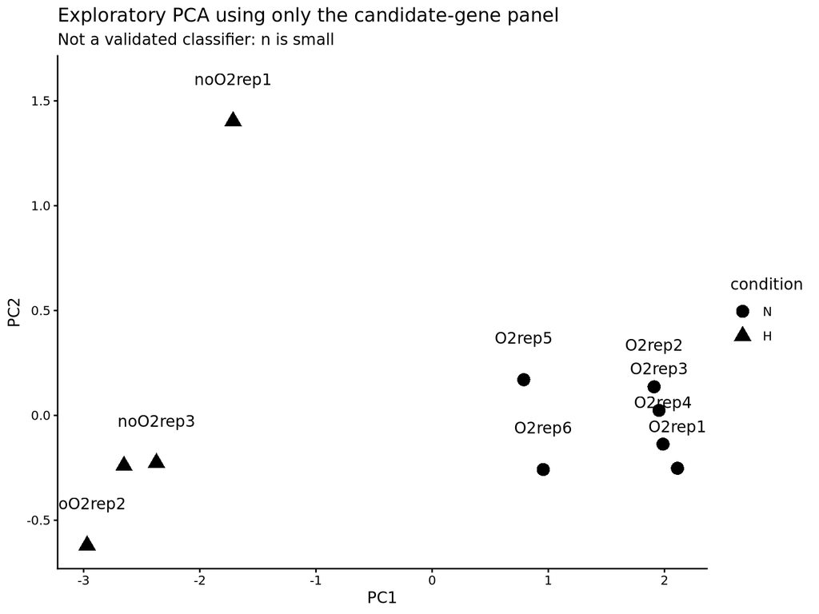

```r
panel <- intersect(candidate_genes, rownames(vsd))

if (length(panel) >= 2) {
  panel_mat <- assay(vsd)[panel, , drop = FALSE]

  pc_panel <- prcomp(
    t(panel_mat),
    center = TRUE,
    scale. = TRUE
  )

  pc_df <- data.frame(
    sample = rownames(pc_panel$x),
    PC1 = pc_panel$x[, 1],
    PC2 = pc_panel$x[, 2],
    condition = colData[rownames(pc_panel$x), "condition"]
  )

  ggplot(pc_df, aes(PC1, PC2, shape = condition, label = sample)) +
    geom_point(size = 4) +
    geom_text(nudge_y = 0.2, check_overlap = TRUE) +
    labs(
      title = "Exploratory PCA using only the candidate-gene panel",
      subtitle = "Not a validated classifier: n is small"
    )
}
```

# 30. Search for an induced/repressed anti-correlated marker pair

```r
vst_mat <- assay(vsd)

up_genes <- res |>
  filter(padj < 0.05, shrunkLFC > 1) |>
  arrange(desc(shrunkLFC)) |>
  slice_head(n = 50) |>
  pull(gene)

down_genes <- res |>
  filter(padj < 0.05, shrunkLFC < -1) |>
  arrange(shrunkLFC) |>
  slice_head(n = 50) |>
  pull(gene)

up_genes <- intersect(up_genes, rownames(vst_mat))
down_genes <- intersect(down_genes, rownames(vst_mat))

if (length(up_genes) > 0 && length(down_genes) > 0) {
  best <- NULL
  best_sep <- -Inf

  for (u in up_genes) {
    for (d in down_genes) {
      marker <- vst_mat[u, ] - vst_mat[d, ]
      means <- tapply(marker, colData$condition, mean)
      sds <- tapply(marker, colData$condition, sd)

      if (all(c("H", "N") %in% names(means))) {
        sep <- abs(means["H"] - means["N"]) /
          (sds["H"] + sds["N"] + 1e-8)

        if (is.finite(sep) && sep > best_sep) {
          best_sep <- sep
          best <- list(up = u, down = d, marker = marker)
        }
      }
    }
  }

  if (!is.null(best)) {
    marker_df <- data.frame(
      sample = names(best$marker),
      marker_score = as.numeric(best$marker),
      condition = colData[names(best$marker), "condition"]
    )

    ggplot(marker_df, aes(condition, marker_score)) +
      geom_boxplot(outlier.shape = NA) +
      geom_jitter(width = 0.08, size = 3) +
      labs(
        title = paste("Exploratory two-gene marker:", best$up, "-", best$down),
        subtitle = paste("Separation score =", round(best_sep, 2)),
        x = "Condition",
        y = "VST(induced gene) - VST(repressed gene)"
      )

    print(best[c("up", "down")])
  }
}
```

```
## $up
## [1] "CPAR2_404850"
##
## $down
## [1] "CPAR2_600600"
```

# 31. Candidate evidence table

```r
candidate_evidence <- final_master |>
  filter(gene %in% candidate_genes) |>
  select(
    gene,
    baseMean,
    log2FoldChange,
    shrunkLFC,
    lfcSE,
    padj,
    effectTestPadj,
    svalue,
    maxCook,
    array_logFC,
    array_FDR_standard,
    array_FDR_robust,
    array_FDR_treat,
    array_sd,
    direction_same,
    platform_difference,
    any_of(c(
      "loo_propFDR05",
      "loo_medianLFC",
      "loo_sdLFC",
      "loo_medianRank",
      "loo_worstRank",
      "edgeR_logFC",
      "edgeR_FDR",
      "rank_product_rank",
      "stat_score",
      "P_top5_weights",
      "P_top10_weights",
      "combined_robustness"
    ))
  )

candidate_evidence
```

```
##           gene  baseMean log2FoldChange shrunkLFC     lfcSE         padj
## 1 CPAR2_603610 7156.4977       3.539613  3.520083 0.2180399 2.404149e-56
## 2 CPAR2_100710  385.8914       3.041895  2.943354 0.3945975 7.729328e-13
## 3 CPAR2_201490 1319.6714       2.852737  2.801407 0.2777908 1.600267e-22
## 4 CPAR2_405010 9437.1333       2.526734  2.488266 0.2432199 5.046353e-23
## 5 CPAR2_203450 3371.8794       6.099724  5.740083 1.0451306 9.675807e-08
##   effectTestPadj       svalue    maxCook array_logFC array_FDR_standard
## 1   2.278684e-28 1.786128e-31 0.07511337    3.381963       1.517112e-04
## 2   1.737989e-05 4.763157e-08 0.70352565    3.071622       3.626108e-05
## 3   3.710561e-09 6.393430e-12 0.62160507    3.531186       7.238432e-06
## 4   4.154604e-08 4.656723e-11 0.81845968    2.719338       3.997215e-05
## 5   6.151374e-05 4.269486e-07 0.27233614    2.501707       2.824438e-04
##   array_FDR_robust array_FDR_treat  array_sd direction_same
## 1     1.799677e-04    1.368501e-03 0.6148848           TRUE
## 2     4.365534e-05    2.816166e-04 0.3536293           TRUE
```

[output cut: 27 more lines]

# 32. Heatmap of candidate evidence scores

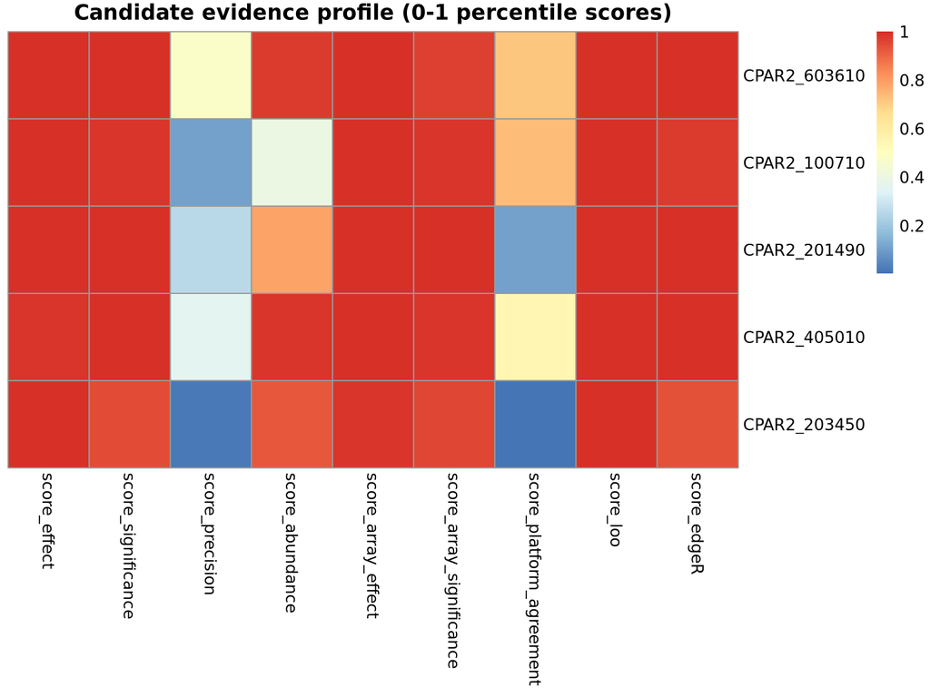

```r
score_heat <- final_master |>
  filter(gene %in% candidate_genes) |>
  select(
    gene,
    score_effect,
    score_significance,
    score_precision,
    score_abundance,
    score_array_effect,
    score_array_significance,
    score_platform_agreement,
    score_loo,
    score_edgeR
  )

if (nrow(score_heat) > 0) {
  rownames(score_heat) <- score_heat$gene
  score_heat$gene <- NULL

  if (requireNamespace("pheatmap", quietly = TRUE)) {
    pheatmap::pheatmap(
      as.matrix(score_heat),
      cluster_rows = FALSE,
      cluster_cols = FALSE,
      main = "Candidate evidence profile (0-1 percentile scores)"
    )
  }
}
```

# 33. Export master results

```r
write.csv(
  final_master,
  file = "~/extended_candidate_master_ranking.csv",
  row.names = FALSE
)

write.csv(
  candidate_evidence,
  file = "~/extended_candidate_evidence.csv",
  row.names = FALSE
)

write.csv(
  rescued,
  file = "~/extended_rescued_candidates.csv",
  row.names = FALSE
)

write.csv(
  fragile,
  file = "~/extended_fragile_original_hits.csv",
  row.names = FALSE
)

if (!is.null(loo_summary)) {
  write.csv(
    loo_summary,
    file = "~/extended_leave_one_out_summary.csv",
    row.names = FALSE
  )
}

if (!is.null(weight_summary)) {
  write.csv(
    weight_summary,
    file = "~/extended_weight_sensitivity.csv",
    row.names = FALSE
  )
}

cat("Main outputs written to your home directory.\n")
```

```
## Main outputs written to your home directory.
```

# 34. Optional command-line / BAM sensitivity plan

These commands require the original BAM files and a compatible BED/GTF annotation, so they are **not executed automatically**. Do not change parameters merely to maximize favorite genes; compare biologically reasonable alternatives.

```bash
# Inspect BAM mapping summaries
samtools flagstat sample.bam
samtools stats sample.bam > sample.stats.txt

# If RSeQC is available, infer library strandedness
infer_experiment.py -r genes.bed -i sample.bam

# BEDTools counting sensitivity:
# - default
bedtools multicov -bams sample.bam -bed genes.bed > counts_default.txt

# - same-strand counting (only if the library orientation warrants it)
bedtools multicov -s -bams sample.bam -bed genes.bed > counts_stranded.txt

# - split alignments (important to test for RNA-seq gene/exon counting)
bedtools multicov -split -bams sample.bam -bed genes.bed > counts_split.txt

# - mapping quality sensitivity
bedtools multicov -q 20 -bams sample.bam -bed genes.bed > counts_mapq20.txt
bedtools multicov -q 30 -bams sample.bam -bed genes.bed > counts_mapq30.txt

# Independent counting with featureCounts; adjust -s after strandedness check.
featureCounts -T 8 -s 0 -a annotation.gtf -o counts_featureCounts.txt *.bam
```

# 35. Optional pathway/GSEA preparation

This script exports a complete ranked list suitable for `fgsea`/`clusterProfiler`. Gene-set definitions for *C. parapsilosis* must be supplied separately and should be documented.

```r
gsea_ranks <- res |>
  filter(is.finite(stat)) |>
  arrange(desc(stat)) |>
  select(gene, stat)

write.table(
  gsea_ranks,
  file = "~/extended_GSEA_ranked_genes.tsv",
  sep = "\t",
  quote = FALSE,
  row.names = FALSE
)
```

# 36. Reproducibility

```r
format(Sys.time(), "%d %B, %Y, %H:%M")
```

```
## [1] "10 September, 2026, 21:35"
```